# Kaspersky Data Part two: Time Series Analysis

Teo Wen Lin

03/10/2020

In this report, a time series analysis is done on cyberthreat data obtained from the Kaspersky Statistics webpage (https://statistics.securelist.com/). In part one, the compilation, cleaning and pre-processing of data was discussed. In part two below, a time series analysis is carried out on two subsets of the data, using the Holt-Winters and ARIMA models.

```r
# Load libraries
library(TTR)
library(stats)
library(forecast)
library(lmtest)
library(ggplot2)
library(dplyr)
library(lubridate)
library(readxl)

# Read data
daily <- read.csv("cleaned/dailydata.csv", stringsAsFactors = FALSE)
hourly <- read.csv("cleaned/hourlydata.csv", stringsAsFactors = FALSE)
```

#### 1. Timezone shifting

As the data displayed on Kaspersky’s Statistics page is in UTC time**, the timezone should be shifted to each country’s local timezone.

```r
# View the data
head(hourly)
```

```
##   X       date hour country local_infection ondemand_scan malicious_mail
## 1 1 2020-08-10    0 Algeria            3056          1503              7
## 2 2 2020-08-10    1 Algeria            2617          1057              3
## 3 3 2020-08-10    2 Algeria            2770           721             10
## 4 4 2020-08-10    3 Algeria            2481           484             19
## 5 5 2020-08-10    4 Algeria            2158           726              6
## 6 6 2020-08-10    5 Algeria            2313           622             23
##   network_attack vulnerabilities  spam
## 1           1145              25 25500
## 2           1020              24 15500
## 3           1074              21 15000
## 4           1072              18  8500
## 5           1088              10 11000
## 6           1058               8 22000
```

```r
hourly[1] <- NULL
hourly$date <- ymd(hourly$date)
str(hourly)
```

```
## 'data.frame':    8064 obs. of  9 variables:
##  $ date           : Date, format: "2020-08-10" "2020-08-10" ...
##  $ hour           : int  0 1 2 3 4 5 6 7 8 9 ...
##  $ country        : chr  "Algeria" "Algeria" "Algeria" "Algeria" ...
##  $ local_infection: num  3056 2617 2770 2481 2158 ...
##  $ ondemand_scan  : num  1503 1057 721 484 726 ...
##  $ malicious_mail : num  7 3 10 19 6 23 43 358 348 344 ...
##  $ network_attack : num  1145 1020 1074 1072 1088 ...
##  $ vulnerabilities: num  25 24 21 18 10 8 37 149 371 145 ...
##  $ spam           : num  25500 15500 15000 8500 11000 22000 15500 30500 29500 44000 ...
```

```r
summary(hourly)
```

```
##       date                 hour         country          local_infection
##  Min.   :2020-08-10   Min.   : 0.00   Length:8064        Min.   :    37
##  1st Qu.:2020-08-20   1st Qu.: 5.75   Class :character   1st Qu.:  2318
##  Median :2020-08-30   Median :11.50   Mode  :character   Median :  9204
##  Mean   :2020-08-30   Mean   :11.50                      Mean   : 29193
##  3rd Qu.:2020-09-10   3rd Qu.:17.25                      3rd Qu.: 16803
##  Max.   :2020-09-20   Max.   :23.00                      Max.   :279983
##  ondemand_scan      malicious_mail   network_attack   vulnerabilities
##  Min.   :    10.0   Min.   :   0.0   Min.   :   213   Min.   :   0.0
##  1st Qu.:   993.8   1st Qu.:  50.0   1st Qu.:  4772   1st Qu.:  23.0
##  Median :  4549.5   Median : 147.0   Median : 18679   Median :  95.0
##  Mean   : 10958.4   Mean   : 372.4   Mean   : 70881   Mean   : 325.6
##  3rd Qu.: 13093.2   3rd Qu.: 447.2   3rd Qu.:124208   3rd Qu.: 522.0
##  Max.   :148912.0   Max.   :5344.0   Max.   :496537   Max.   :3092.0
##       spam
##  Min.   :       0
##  1st Qu.:   86000
##  Median :  264750
##  Mean   : 2179460
##  3rd Qu.: 2547625
##  Max.   :40955500
```

```r
# Combine date and time into 1 column

hourly$datetime <- paste0(as.character(hourly$date), " ", as.character(hourly$hour), ":00:00")
hourly$datetime <- ymd_hms(hourly$datetime)
hourly <- hourly[, c(10,3:9)]# remove date and hour columns, leaving only datetime
```

```r
# Split data into separate countries

algeria <- hourly[hourly$country == 'Algeria',]
australia <- hourly[hourly$country == 'Australia',]
bangladesh <- hourly[hourly$country == 'Bangladesh',]
china <- hourly[hourly$country == "China",]
india <- hourly[hourly$country == 'India',]
russia <- hourly[hourly$country == 'Russia',]
singapore <- hourly[hourly$country == 'Singapore',]
us <- hourly[hourly$country == 'United States',]

# Algeria (UTC+1) "Africa/Algiers"
algeria$datetimelocal <- as.character(with_tz(algeria$datetime, "Africa/Algiers"))
head(algeria[1:4], 4)
```

```
##              datetime country local_infection ondemand_scan
## 1 2020-08-10 00:00:00 Algeria            3056          1503
## 2 2020-08-10 01:00:00 Algeria            2617          1057
## 3 2020-08-10 02:00:00 Algeria            2770           721
## 4 2020-08-10 03:00:00 Algeria            2481           484
```

```r
# Bangladesh (UTC+6) "Asia/Dhaka"
bangladesh$datetimelocal <- as.character(with_tz(bangladesh$datetime, "Asia/Dhaka"))
head(bangladesh[1:4], 4)
```

```
##                 datetime    country local_infection ondemand_scan
## 2017 2020-08-10 00:00:00 Bangladesh            1548           223
## 2018 2020-08-10 01:00:00 Bangladesh            2847           461
## 2019 2020-08-10 02:00:00 Bangladesh            7631          1898
## 2020 2020-08-10 03:00:00 Bangladesh           15471          4648
```

```r
# China (UTC+8) "Asia/Chungking"
china$datetimelocal <- as.character(with_tz(china$datetime, "Asia/Chungking"))
head(china[1:4], 4)
```

```
##                 datetime country local_infection ondemand_scan
## 3025 2020-08-10 00:00:00   China           27901         12923
## 3026 2020-08-10 01:00:00   China           28846         12614
## 3027 2020-08-10 02:00:00   China           26406         10248
## 3028 2020-08-10 03:00:00   China           24335          9574
```

```r
# India (UTC+5.5) "Asia/Kolkata"
india$datetimelocal <- as.character(with_tz(india$datetime, "Asia/Kolkata"))
head(india[1:4], 4)
```

```
##                 datetime country local_infection ondemand_scan
## 4033 2020-08-10 00:00:00   India            2940          1047
## 4034 2020-08-10 01:00:00   India            5681          1708
## 4035 2020-08-10 02:00:00   India           13003          4032
## 4036 2020-08-10 03:00:00   India           29165         10549
```

```r
# Singapore (UTC+8) "Singapore"
singapore$datetimelocal <- as.character(with_tz(singapore$datetime, "Singapore"))
head(singapore[1:4], 4)
```

```
##                 datetime   country local_infection ondemand_scan
## 6049 2020-08-10 00:00:00 Singapore             185           104
## 6050 2020-08-10 01:00:00 Singapore             222            82
## 6051 2020-08-10 02:00:00 Singapore             305           508
## 6052 2020-08-10 03:00:00 Singapore             355           413
```

```r
# Russia (UTC+3) "Europe/Moscow"
russia$datetimelocal <- as.character(with_tz(russia$datetime, "Europe/Moscow"))
head(russia[1:4], 4)
```

```
##                 datetime country local_infection ondemand_scan
## 5041 2020-08-10 00:00:00  Russia           90791         31914
## 5042 2020-08-10 01:00:00  Russia          101711         30163
## 5043 2020-08-10 02:00:00  Russia          102861         31501
## 5044 2020-08-10 03:00:00  Russia          132789         39811
```

```r
#   US (UTC-5) "US/Mountain"
us$datetimelocal <- as.character(with_tz(us$datetime, "US/Mountain"))
head(us[1:4], 4)
```

```
##                 datetime       country local_infection ondemand_scan
## 7057 2020-08-10 00:00:00 United States           12396          7454
## 7058 2020-08-10 01:00:00 United States           12144          8298
## 7059 2020-08-10 02:00:00 United States           11426          6887
## 7060 2020-08-10 03:00:00 United States           10857          6053
```

```r
# Australia (UTC+10) "Australia/Brisbane"
australia$datetimelocal <- as.character(with_tz(australia$datetime, "Australia/Brisbane"))
head(australia[1:4], 4)
```

```
##                 datetime   country local_infection ondemand_scan
## 1009 2020-08-10 00:00:00 Australia            2767          1831
## 1010 2020-08-10 01:00:00 Australia            2936          1943
## 1011 2020-08-10 02:00:00 Australia            2566          1997
## 1012 2020-08-10 03:00:00 Australia            2465          1785
```

As some countries had more than one timezone (see in particular Russia which spans 9 different time zones), but data was displayed in a single time zone (UTC), each country’s data was converted to the time zone of the region with the highest population.

```r
# Combine into new file
# The datetimelocal column must be in character format and not POSIXct format, otherwise it will revert back to UTC time when different timezones are combined.

newdata <- rbind(algeria, australia, bangladesh, china, india,
                 russia, singapore, us)
newdata <- newdata[, c(2, 1, 9, 3:8)]

# Create new date and hour columns
newdata$date <- date(newdata$datetimelocal)
newdata$time <- hour(newdata$datetimelocal)
newdata <- newdata[, c(1:3, 10:11, 4:9)]
rownames(newdata) <- NULL
head(newdata)
```

```
##   country            datetime       datetimelocal       date time
## 1 Algeria 2020-08-10 00:00:00 2020-08-10 01:00:00 2020-08-10    1
## 2 Algeria 2020-08-10 01:00:00 2020-08-10 02:00:00 2020-08-10    2
## 3 Algeria 2020-08-10 02:00:00 2020-08-10 03:00:00 2020-08-10    3
## 4 Algeria 2020-08-10 03:00:00 2020-08-10 04:00:00 2020-08-10    4
## 5 Algeria 2020-08-10 04:00:00 2020-08-10 05:00:00 2020-08-10    5
## 6 Algeria 2020-08-10 05:00:00 2020-08-10 06:00:00 2020-08-10    6
##   local_infection ondemand_scan malicious_mail network_attack vulnerabilities
## 1            3056          1503              7           1145              25
## 2            2617          1057              3           1020              24
## 3            2770           721             10           1074              21
## 4            2481           484             19           1072              18
## 5            2158           726              6           1088              10
## 6            2313           622             23           1058               8
##    spam
## 1 25500
## 2 15500
## 3 15000
## 4  8500
## 5 11000
## 6 22000
```

### 2. Preparing data for time series analysis

To carry out time series analysis, we first create a time series object from a subset of the data that we intend to analyse. For this report, we will focus on local infections and network attacks in the US.

```r
# Subset US local infection
us.local <- newdata[newdata$country == "United States",1:6]
head(us.local)
```

```
##            country            datetime       datetimelocal       date time
## 7057 United States 2020-08-10 00:00:00 2020-08-09 18:00:00 2020-08-09   18
## 7058 United States 2020-08-10 01:00:00 2020-08-09 19:00:00 2020-08-09   19
## 7059 United States 2020-08-10 02:00:00 2020-08-09 20:00:00 2020-08-09   20
## 7060 United States 2020-08-10 03:00:00 2020-08-09 21:00:00 2020-08-09   21
## 7061 United States 2020-08-10 04:00:00 2020-08-09 22:00:00 2020-08-09   22
## 7062 United States 2020-08-10 05:00:00 2020-08-09 23:00:00 2020-08-09   23
##      local_infection
## 7057           12396
## 7058           12144
## 7059           11426
## 7060           10857
## 7061           10783
## 7062           10039
```

```r
summary(us.local)
```

```
##    country             datetime                   datetimelocal
##  Length:1008        Min.   :2020-08-10 00:00:00   Length:1008
##  Class :character   1st Qu.:2020-08-20 11:45:00   Class :character
##  Mode  :character   Median :2020-08-30 23:30:00   Mode  :character
##                     Mean   :2020-08-30 23:30:00
##                     3rd Qu.:2020-09-10 11:15:00
##                     Max.   :2020-09-20 23:00:00
##       date                 time       local_infection
##  Min.   :2020-08-09   Min.   : 0.00   Min.   : 1627
##  1st Qu.:2020-08-20   1st Qu.: 5.75   1st Qu.:12136
##  Median :2020-08-30   Median :11.50   Median :13931
##  Mean   :2020-08-30   Mean   :11.50   Mean   :13821
##  3rd Qu.:2020-09-10   3rd Qu.:17.25   3rd Qu.:15431
##  Max.   :2020-09-20   Max.   :23.00   Max.   :19223
```

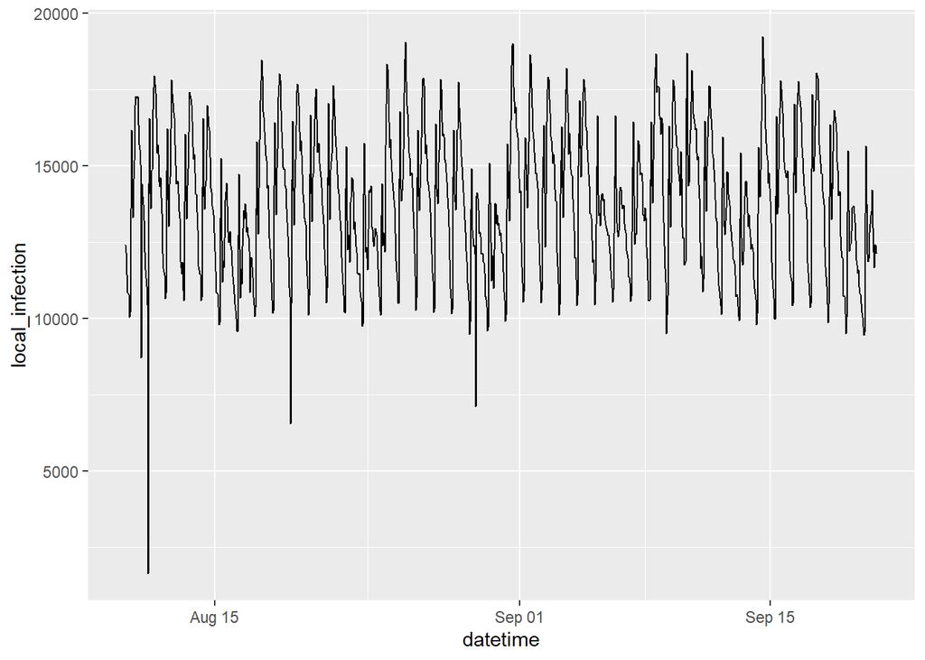

```r
us.local%>%
  ggplot(aes(x=datetime,y=local_infection))+geom_line()
```

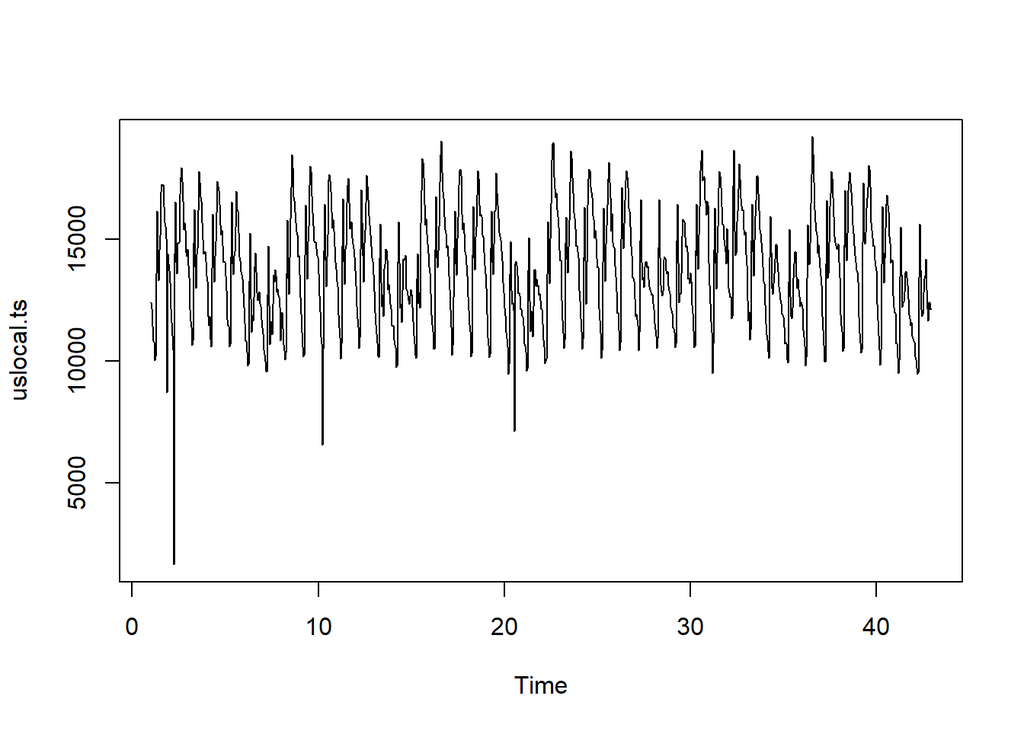

```r
# Create Time Series using US Local Infections

# First set: frequency of 24 hours
uslocal.ts <- ts(us.local$local_infection, frequency=24)
plot(uslocal.ts)
```

```r
# Second set: frequency of 168 hours (7 days)
uslocal.ts2 <- ts(us.local$local_infection, frequency=168)
# plot(uslocal.ts2)
```

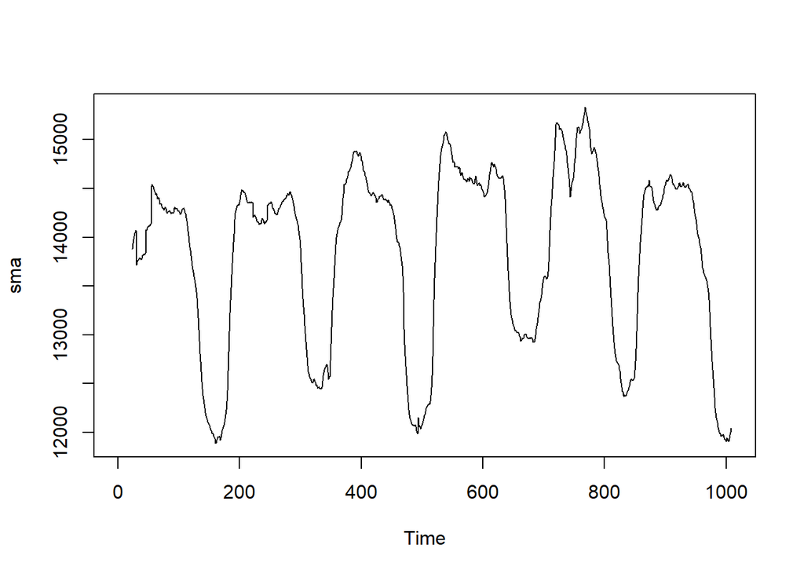

```r
# Plotting the simple moving average with frequency of 24 and 168
sma <- SMA(uslocal.ts, n=24)
plot.ts(sma) # smoothing with order=24 reveals the weekly trend
```

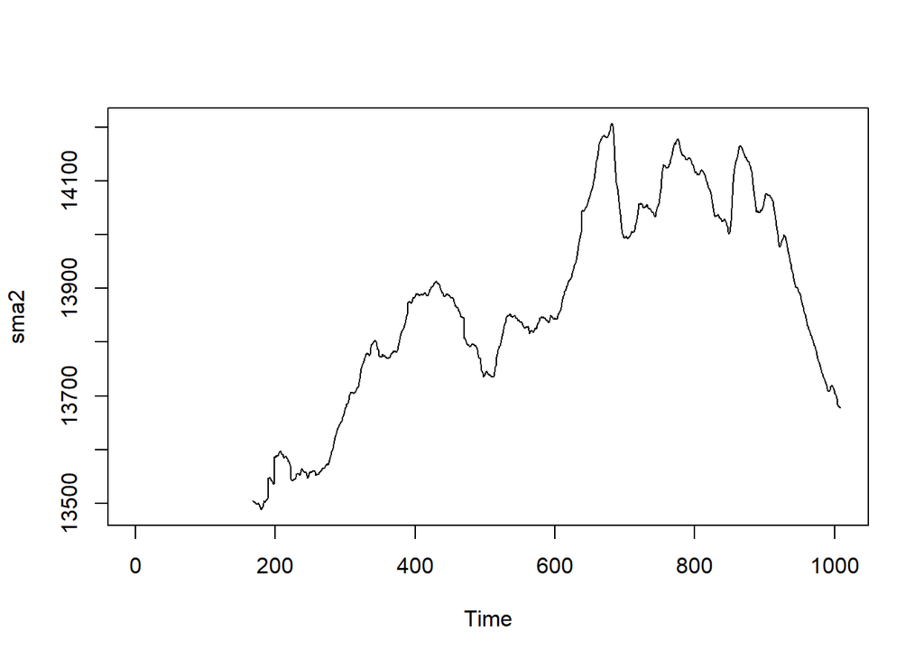

```r
sma2 <- SMA(uslocal.ts, n=168)
plot.ts(sma2) # smoothing with order=168 shows an irregular overall trend
```

```r
length(uslocal.ts)
```

```
## [1] 1008
```

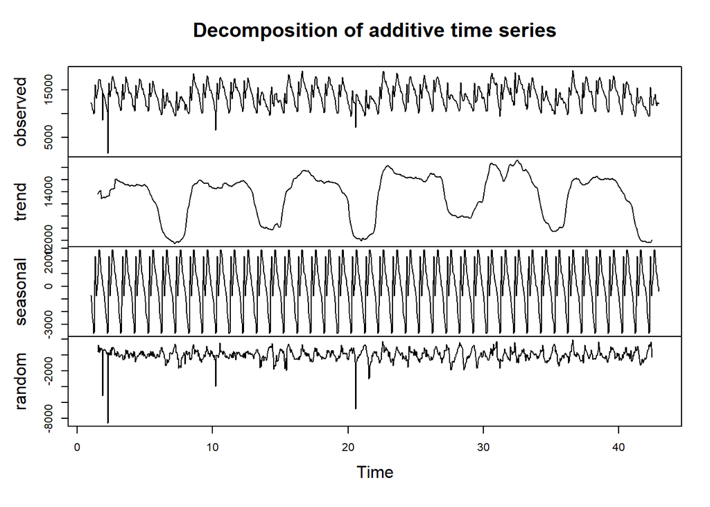

```r
# Decomposing the time series with frequency = 24
plot(decompose(uslocal.ts))
```

Using frequency of 24, only the daily trend shows up in the seasonal component. The weekly seasons are not captured in the seasonal component but are part of the trend component.

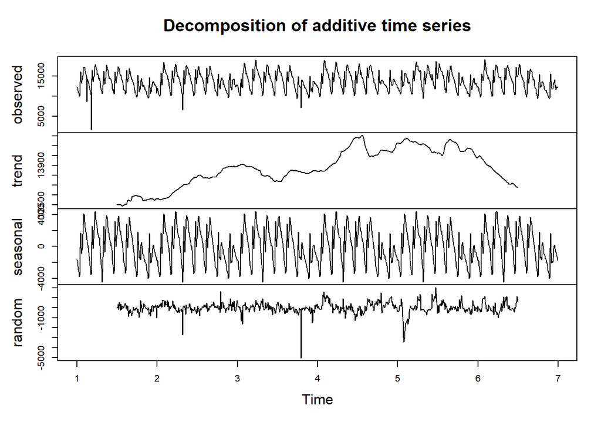

```r
# Decomposing the time series with frequency = 168
plot(decompose(uslocal.ts2))
```

The decomposed plot of local infections in the US with frequency of 168 shows that there is a clear daily and weekly trend. It also shows what appears to be an increase, followed by a decrease in the overall trend during the period of 11 August to 19 September. This could be part of a larger cyclical fluctuation, or simply random fluctuations.

A closer look at the overall trend:

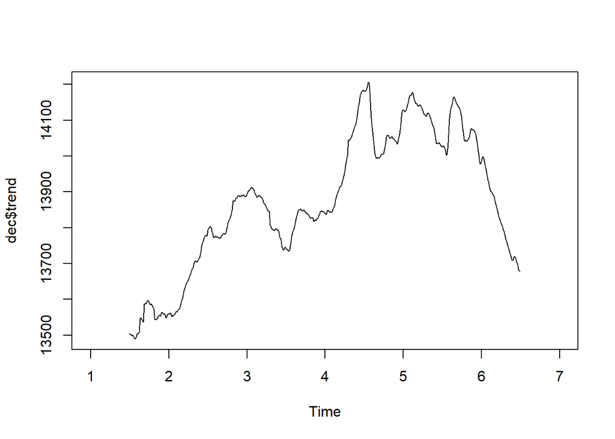

```r
dec <- decompose(uslocal.ts2)
plot(dec$trend)
```

This plot is the same as the SMA plot above. As daily and weekly trends are both captured in seasonal component, the overall trend is revealed which appears to be somewhat random.

Next, we divide the data into train and test sets. We do this for the 2 time series datasets with frequency = 24 and with frequency = 168, to observe the differences between the two.

```r
# Train and test sets using freq = 24

train.uslocal_ = subset(uslocal.ts, end=length(uslocal.ts)-168) # first 840 values (5 weeks)
test.uslocal_ = subset(uslocal.ts, start=length(uslocal.ts)-167) # last 168 values (1 week)
```

#### 3. Holt-Winters models

There are a few packages which can be used to build a Holt-Winters model.

3.1 First is the HoltWinters function found in base R.

```r
# Using HoltWinters function built into base R
train_ <- HoltWinters(train.uslocal_)
summary(train_)
```

```
##              Length Class  Mode
## fitted       3264   mts    numeric
## x             840   ts     numeric
## alpha           1   -none- numeric
## beta            1   -none- numeric
## gamma           1   -none- numeric
## coefficients   26   -none- numeric
## seasonal        1   -none- character
## SSE             1   -none- numeric
## call            2   -none- call
```

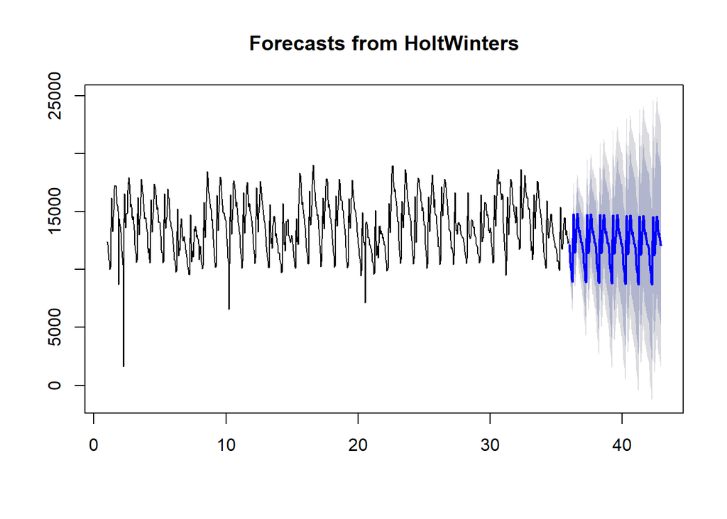

```r
trainforecast_ <- forecast:::forecast.HoltWinters(train_, h=168)
plot(trainforecast_)
```

The forecast using the dataset with frequency of 24 (hours) can only forecast the daily fluctuation. It does not capture the weekly fluctation, in particular the significant differences between weekdays and weekends.

```r
accuracy(trainforecast_)
```

```
##                      ME     RMSE     MAE         MPE     MAPE      MASE
## Training set -0.6871493 845.0392 527.563 -0.09444402 3.963936 0.5767645
##                   ACF1
## Training set 0.1790206
```

Despite only predicting daily fluctuations, the accuracy of the forecast on the training set seems fairly good, with an MAPE of 3.96%.

3.2 We also try using the Holt-Winters function in the forecast package.

```r
# Using hw function in forecast package
hw1.uslocal <- hw(train.uslocal_, model = "AMM", h=168)
hw1.uslocal$model
```

```
## Holt-Winters' additive method
##
## Call:
##  hw(y = train.uslocal_, h = 168, model = "AMM")
##
##   Smoothing parameters:
##     alpha = 0.5963
##     beta  = 4e-04
##     gamma = 1e-04
##
##   Initial states:
##     l = 14913.3068
##     b = 17.5567
##     s = -347.6694 -11.2454 93.6398 626.0615 1023.322 1152.04
##            1732.469 2327.957 2858.806 2801.538 1679.533 686.7647 38.409 -861.5118 49.0483 2296.851 477.4557 -3633.885 -3691.497 -2824.202 -2514.288 -2074.099 -1194.531 -690.9678
##
##   sigma:  718.8315
##
##      AIC     AICc      BIC
## 16735.99 16738.14 16873.26
```

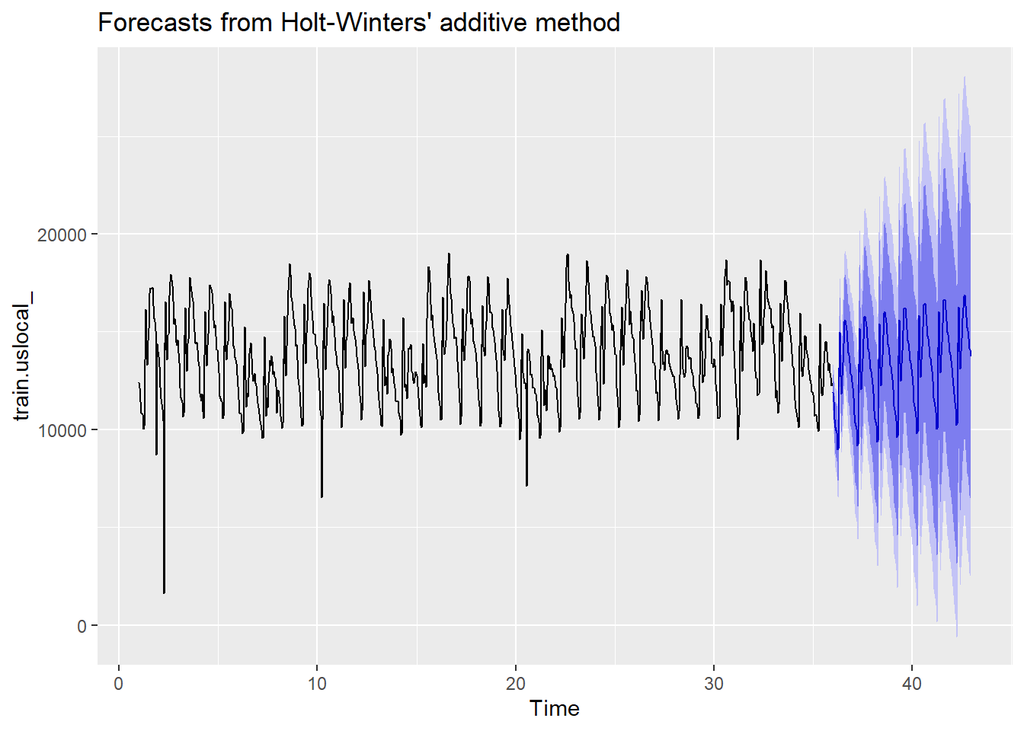

```r
autoplot(hw1.uslocal)
```

```r
accuracy(hw1.uslocal)
```

```
##                     ME     RMSE      MAE        MPE     MAPE      MASE
## Training set -26.32979 706.7494 405.4854 -0.9238244 3.647855 0.4433017
##                     ACF1
## Training set 0.005237116
```

The accuracy of this model is similar, with MAPE of 3.65.

We add this forecast to a dataframe of forecasts, so that we can compare the accuracy of different models. We use the prediction from the forecast package, rather than from base R, as the MAPE on train is slightly better.

```r
# Create dataframe
trainforecast.df_ <- data.frame(hw1.uslocal)
# head(trainforecast.df_)
# dim(trainforecast.df_)
trainforecast.df_$Actual <- as.numeric(test.uslocal_)
colnames(trainforecast.df_)[1] <- "Holtwinters.Predict"
```

3.3 Next, we try the double-seasonality Holt-Winters function from the dshw package. This allows 2 seasons to be input, thus we input the daily and weekly periods.

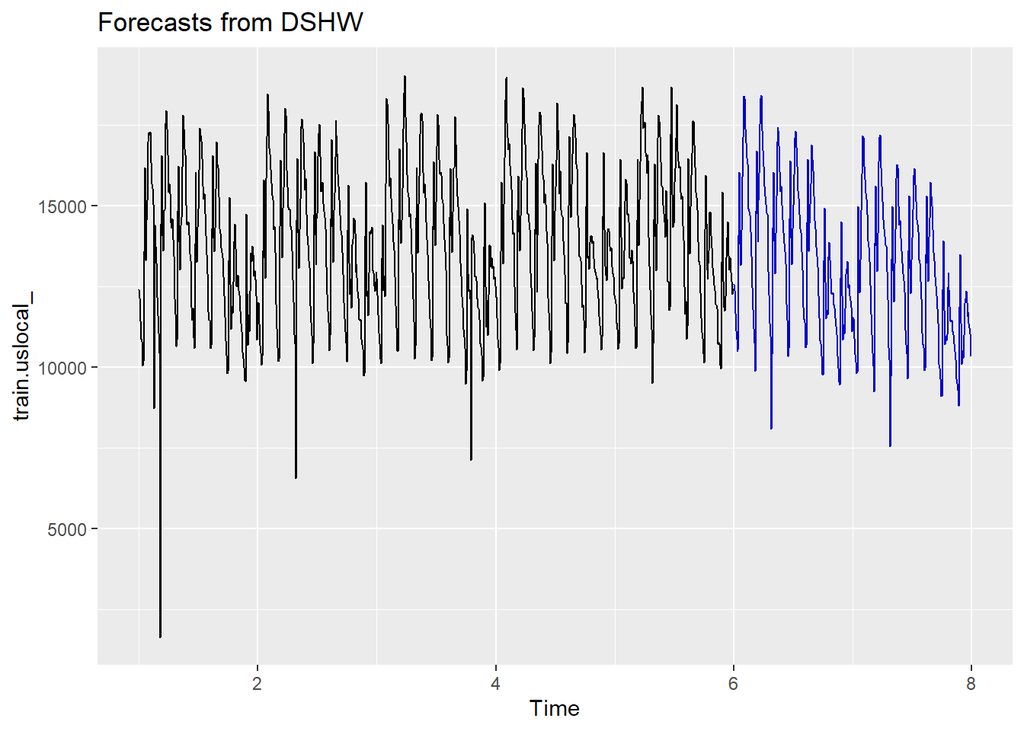

```r
# Using double-seasonality Holt-Winters forecasting
hw2.uslocal <- forecast::dshw(train.uslocal_, period1=24, period2=168)
# summary(hw2.uslocal)
# hw2.uslocal$model # commented out as it is too long
autoplot(hw2.uslocal)
```

As expected, this model captures both daily and weekly seasons.

```r
accuracy(hw2.uslocal) # MAPE on train: 3.41
```

```
##                    ME    RMSE      MAE        MPE     MAPE      MASE
## Training set 16.96316 698.607 378.2995 -0.5310008 3.412932 0.6375411
##                     ACF1
## Training set -0.02193381
```

The accuracy is better than the previous model, with MAPE of 3.41 on the train set.

```r
# Add the predictions from this model to the forecast dataframe
train.df_ <- data.frame(hw2.uslocal)
tail(train.df_)
```

```
##       Point.Forecast
## 7.964       11577.73
## 7.970       11682.91
## 7.976       11364.10
## 7.982       11214.80
## 7.988       11024.41
## 7.994       10315.39
```

```r
trainforecast.df_$dshw.Predict <- train.df_[1:168,]
# Remove the Lo and High prediction boundaries
trainforecast.df_[2:5] <- NULL

# Add in actual values from test set
trainforecast.df_$datetime <- us.local$datetimelocal[841:1008]
trainforecast.df_$datetime <- ymd_hms(trainforecast.df_$datetime)

# Rearrange columns
trainforecast.df_ <- trainforecast.df_[, c(4,2,1,3)]
```

```r
# Calculate MAPE errors for HW prediction, on test dataset
trainforecast.df_$HW.MAE <- abs(trainforecast.df_$Actual - trainforecast.df_$Holtwinters.Predict)
trainforecast.df_$HW.MAPE <- trainforecast.df_$HW.MAE * 100 / trainforecast.df_$Actual

HW.MAE <- mean(trainforecast.df_$HW.MAE)
HW.MAPE <- mean(trainforecast.df_$HW.MAPE)
HW.MAPE # MAPE on test: 10.1
```

```
## [1] 10.13202
```

```r
# Calculate MAPE errors for DSHW prediction, on test dataset
trainforecast.df_$dshw.MAE <- abs(trainforecast.df_$Actual - trainforecast.df_$dshw.Predict)
trainforecast.df_$dshw.MAPE <- trainforecast.df_$dshw.MAE * 100 / trainforecast.df_$Actual

dshw.MAE <- mean(trainforecast.df_$dshw.MAE)
dshw.MAPE <- mean(trainforecast.df_$dshw.MAPE)
dshw.MAPE # MAPE on test: 3.57 - about the same result as freq = 168 below, because dshw takes into account both daily and weekly seasonalities
```

```
## [1] 3.573592
```

3.4 We now repeat this process, using the dataset with frequency = 168.

```r
# Train and test sets using freq = 168
train.uslocal = subset(uslocal.ts2, end=length(uslocal.ts2)-168) # first 840 values (5 weeks)
test.uslocal = subset(uslocal.ts2, start=length(uslocal.ts2)-167) # last 168 values (1 week)
```

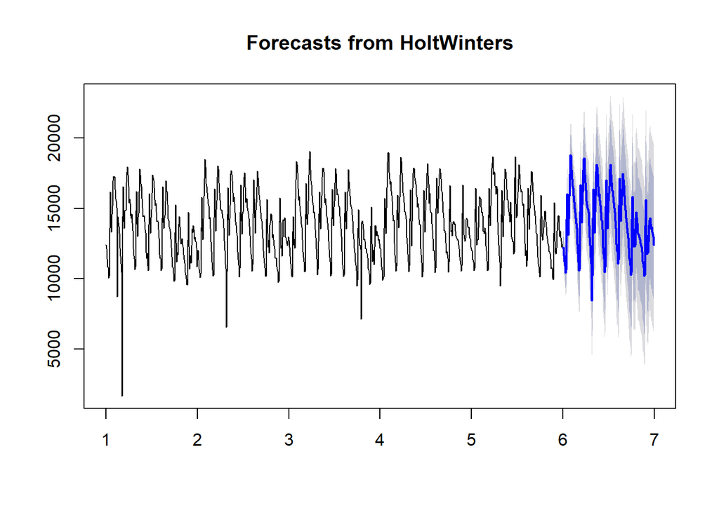

```r
# Using HoltWinters function built into base R
train <- HoltWinters(train.uslocal)
# summary(train)
trainforecast <- forecast:::forecast.HoltWinters(train, h=168)
plot(trainforecast)
```

```r
accuracy(trainforecast) # MAPE on train: 2.62
```

```
##                     ME     RMSE      MAE        MPE     MAPE     MASE
## Training set -1.486968 571.1423 350.0591 -0.1315093 2.621451 0.589948
##                    ACF1
## Training set 0.07915498
```

```r
# summary(trainforecast)
```

```r
# Add to new dataframe
trainforecast.df <- data.frame(trainforecast)
head(trainforecast.df)
```

```
##          Point.Forecast     Lo.80    Hi.80     Lo.95    Hi.95
## 6.000000       12181.48 11448.986 12913.97 11061.229 13301.73
## 6.005952       12198.09 11393.085 13003.10 10966.939 13429.25
## 6.011905       11655.82 10784.303 12527.33 10322.951 12988.68
## 6.017857       11204.67 10271.377 12137.96  9777.323 12632.02
## 6.023810       10923.50  9932.278 11914.73  9407.554 12439.45
## 6.029762       10418.59  9372.628 11464.54  8818.931 12018.24
```

```r
dim(trainforecast.df)
```

```
## [1] 168   5
```

```r
trainforecast.df$Actual <- as.numeric(test.uslocal)
colnames(trainforecast.df)[1] <- "Holtwinters.Predict"
```

We cannot use the hw function from the forecast package on this dataset, because this function does not accept a frequency higher than 24. (see: https://robjhyndman.com/hyndsight/longseasonality/)

```r
# Using hw function in forecast package does not work with freq 168
# hw2.uslocal <- hw(train.uslocal, model = "AMM")
# hw2.uslocal$model
# plot(hw2.uslocal)
# accuracy(hw2.uslocal)
```

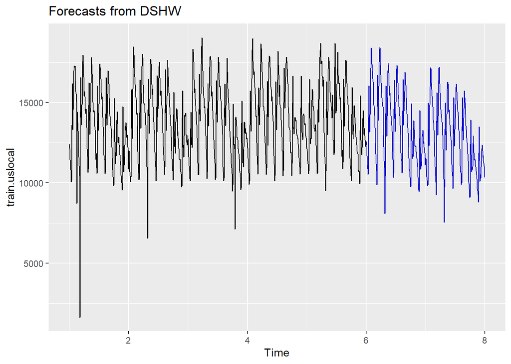

```r
# Using double-seasonality Holt-Winters forecasting
hw3.uslocal <- forecast::dshw(train.uslocal, period1=24, period2=168)
# summary(hw3.uslocal)
# hw3.uslocal$model
autoplot(hw3.uslocal)
```

```r
accuracy(hw3.uslocal) # MAPE on train: 3.41
```

```
##                    ME    RMSE      MAE        MPE     MAPE      MASE
## Training set 16.96316 698.607 378.2995 -0.5310008 3.412932 0.6375411
##                     ACF1
## Training set -0.02193381
```

```r
# Add forecasts to dataframe
train.df2 <- data.frame(hw3.uslocal)

trainforecast.df$dshw.Predict <- train.df2[1:168,]
trainforecast.df[2:5] <- NULL

trainforecast.df$datetime <- us.local$datetimelocal[841:1008]
trainforecast.df$datetime <- ymd_hms(trainforecast.df$datetime)
trainforecast.df <- trainforecast.df[, c(4,2,1,3)]
trainforecast.df$HW.MAE <- abs(trainforecast.df$Actual - trainforecast.df$Holtwinters.Predict)
trainforecast.df$HW.MAPE <- trainforecast.df$HW.MAE * 100 / trainforecast.df$Actual

HW.MAE <- mean(trainforecast.df$HW.MAE)
HW.MAPE <- mean(trainforecast.df$HW.MAPE)
HW.MAPE # MAPE on test: 4.88
```

```
## [1] 4.882395
```

```r
trainforecast.df$dshw.MAE <- abs(trainforecast.df$Actual - trainforecast.df$dshw.Predict)
trainforecast.df$dshw.MAPE <- trainforecast.df$dshw.MAE * 100 / trainforecast.df$Actual

dshw.MAE <- mean(trainforecast.df$dshw.MAE)
dshw.MAPE <- mean(trainforecast.df$dshw.MAPE)
dshw.MAPE # MAPE on test: 3.57
```

```
## [1] 3.573592
```

#### 4. ARIMA models

Next, we attempt to build ARIMA models on the dataset. As there are seasons in the data and a possible overall trend, each component (AR, I and MA) is likely to be needed.

4.1 First, using the available packages in R, which are the basic stats package and the forecast package. These codes were only successfully run once, as the machine tended to take very long or freeze when running them. They are therefore commented out in the code chunk below.

```r
# NOTE: Codes were only run once as local device froze when run a second time onwards

# using arima from basic stats package
# model1 = arima(train.uslocal, order = c(1,1,2), seasonal=c(0,2,2))
# summary(model1)
# coeftest(model1)
#
# # model tuning
# model2 = arima(train.uslocal, order = c(1,1,1), seasonal=c(0,1,1))
# summary(model2)
# coeftest(model2)
# acf(model2, lag.max=50)
# pacf(model2, lag.max=50)
# Box.test(model2$residuals, lag=20, type="Ljung-Box")
#
# model3 = arima(train.uslocal, order = c(1,1,2), seasonal=c(0,1,1))
# summary(model3)
# coeftest(model3)
# acf(model3, lag.max=50)
# pacf(model3, lag.max=50)
# Box.test(model3$residuals, lag=20, type="Ljung-Box")
#
# model4 = arima(train.uslocal, order = c(1,1,2), seasonal=c(1,1,1))
# summary(model4)
# coeftest(model4)
# acf(model4, lag.max=50)
# pacf(model4, lag.max=50)
# Box.test(model4$residuals, lag=20, type="Ljung-Box")
#
# # Using Arima from forecast package
# model5 = Arima(train.uslocal, order = c(1,1,2), seasonal=c(0,2,2))
# summary(model5)
# coeftest(model5)
# forecast(model5)
# acf(model5, lag.max=20)
# pacf(model5, lag.max=50)
# Box.test(model5$residuals, lag=20, type="Ljung-Box")
#
# checkresiduals(model5)
#
# # forecast the next 168 values
# forecasted_values = forecast(model4, 168)
# forecasted_values
# # visual inspection of forecast
# autoplot(forecasted_values, lwd=8)
#
# # Using Auto-ARIMA to complement manual tuning
#
# fitAutoArima = auto.arima(uslocal.ts)
# fitAutoArima # different model - ARIMA(1,0,1)(2,1,0)[24]
# coeftest(fitAutoArima) # p values
# accuracy(fitAutoArima) # not as good as model4 accuracy
```

4.2 As an alternative, JMP software was used to build ARIMA models. The result of the best 3 models, and 1 more for contrast, were saved in a csv file and imported.

```r
# Import JMP Arima models
arima.p <- read_xlsx("analysis/us_predict.xlsx", sheet = 1, range="D505:G672", col_names=c("Predict_112022", "Predict_222022", "Predict_222122", "Predict_112012"))
dim(arima.p)
```

```
## [1] 168   4
```

```r
colnames(arima.p)
```

```
## [1] "Predict_112022" "Predict_222022" "Predict_222122" "Predict_112012"
```

```r
trainforecast.df$Arima1 <- arima.p$Predict_112022
trainforecast.df$Arima2 <- arima.p$Predict_222022
trainforecast.df$Arima3 <- arima.p$Predict_222122
trainforecast.df$Arima4 <- arima.p$Predict_112012
```

### 5. Comparison of the various models on local infection data in US

A graph is created to visualise the results of each model built against the actual values of the test dataset.

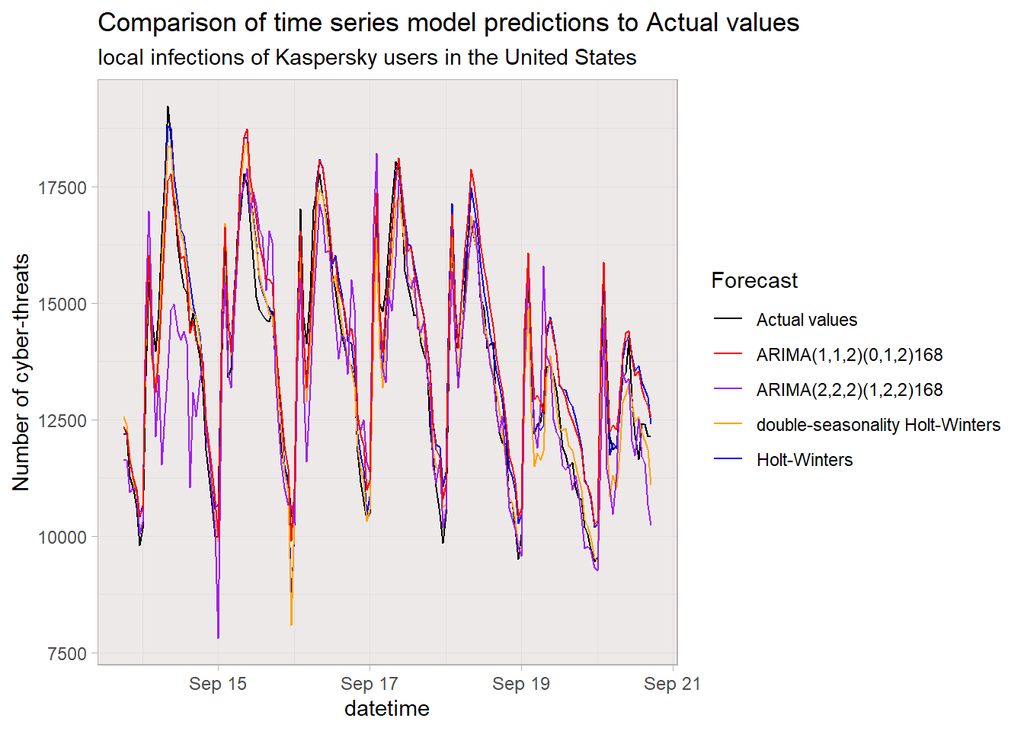

```r
# Plot forecasts and actual
ggplot(data = trainforecast.df) +
  geom_line(aes(x = datetime, y = Actual, color = "Actual values")) +
  geom_line(aes(x = datetime, y = Holtwinters.Predict, color = "Holt-Winters")) +
  geom_line(aes(x = datetime, y = dshw.Predict,
                color = "double-seasonality Holt-Winters")) +
  geom_line(aes(x = datetime, y = Arima2, color = "ARIMA(2,2,2)(1,2,2)168")) +
  geom_line(aes(x = datetime, y = Arima4, color = "ARIMA(1,1,2)(0,1,2)168")) +
  theme_light() +
  labs(title = "Comparison of time series model predictions to Actual values",
       subtitle = "local infections of Kaspersky users in the United States") +
  theme(legend.position = "right",
        panel.background = element_rect(fill = 'snow2'),
        axis.text.x = element_text(size=9)) +
  scale_fill_identity(name = 'Forecast', guide = 'legend') +
  scale_colour_manual(name = "Forecast", values = c('black', 'red', 'purple','orange', "blue")) +
  scale_y_continuous(name='Number of cyber-threats')
```

```r
 # scale_x_datetime(name = 'Datetime'))
```

Each model performs fairly well as the data is quite orderly and predictable.

Surprisingly, the ARIMA model which was weighted lowly in JMP’s model comparison (due to high AIC value, although it had a lower MAPE than the highly-weighted models) performed better than the others on the test set.

#### 6. Time series models on Network Attack data in the US

Our next dataset is network attack data in the US. We carry out the same steps as shown above for the local infection data.

```r
# Running models on US Network Attacks

us.net <- newdata[newdata$country == "United States",c(1:5,9)]
head(us.net)
```

```
##            country            datetime       datetimelocal       date time
## 7057 United States 2020-08-10 00:00:00 2020-08-09 18:00:00 2020-08-09   18
## 7058 United States 2020-08-10 01:00:00 2020-08-09 19:00:00 2020-08-09   19
## 7059 United States 2020-08-10 02:00:00 2020-08-09 20:00:00 2020-08-09   20
## 7060 United States 2020-08-10 03:00:00 2020-08-09 21:00:00 2020-08-09   21
## 7061 United States 2020-08-10 04:00:00 2020-08-09 22:00:00 2020-08-09   22
## 7062 United States 2020-08-10 05:00:00 2020-08-09 23:00:00 2020-08-09   23
##      network_attack
## 7057         178370
## 7058         167902
## 7059         155932
## 7060         135987
## 7061         106045
## 7062          96345
```

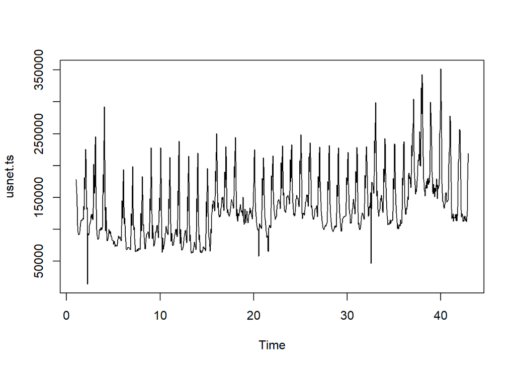

```r
usnet.ts <- ts(us.net$network_attack, frequency=24)
plot(usnet.ts)
```

```r
length(usnet.ts)
```

```
## [1] 1008
```

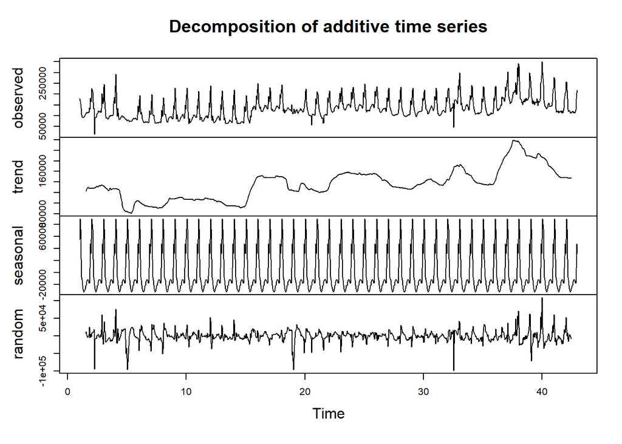

```r
plot(decompose(usnet.ts))
```

The network attack data is less orderly, and appears to have an upward overall trend.

```r
# Train and test sets
train.usnet = subset(usnet.ts, end=length(usnet.ts)-168) # first 840 values (5 weeks)
test.usnet = subset(usnet.ts, start=length(usnet.ts)-167) # last 168 values (1 week)
```

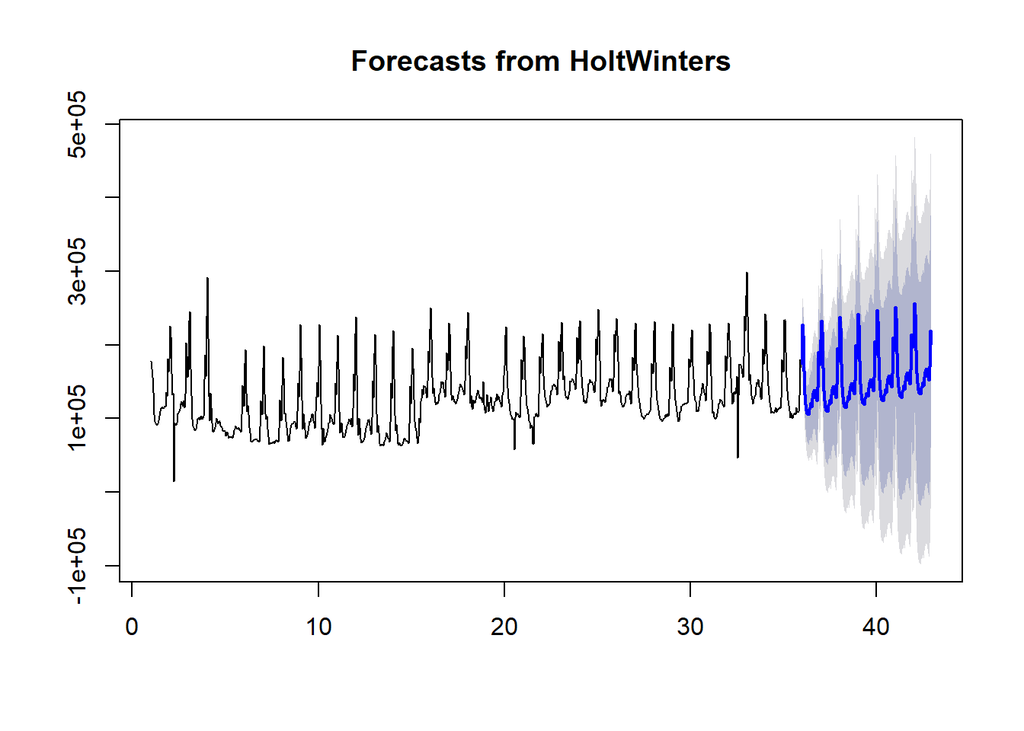

```r
# HoltWinters
trainnet <- HoltWinters(train.usnet)
trainnet.fc <- forecast:::forecast.HoltWinters(trainnet, h=168)
plot(trainnet.fc)
```

```r
# summary(trainnet.fc)
```

```r
accuracy(trainnet.fc)
```

```
##                     ME     RMSE      MAE        MPE     MAPE      MASE
## Training set -304.0908 15702.39 9748.253 -0.9093578 8.381547 0.5950423
##                   ACF1
## Training set 0.1915711
```

```r
net.df <- data.frame(trainnet.fc)
head(net.df)
```

```
##          Point.Forecast     Lo.80    Hi.80     Lo.95    Hi.95
## 36.00000       175129.5 154997.54 195261.5 144340.31 205918.8
## 36.04167       228193.4 204824.18 251562.7 192453.25 263933.6
## 36.08333       212571.3 186361.62 238781.0 172487.06 252655.5
## 36.12500       164218.9 135447.85 192989.9 120217.39 208220.3
## 36.16667       133039.6 101917.33 164161.9  85442.19 180637.0
## 36.20833       119471.3  86163.32 152779.3  68531.14 170411.4
```

```r
net.df$Actual <- as.numeric(test.usnet)
colnames(net.df)[1] <- "Holtwinters.Predict"
```

```r
# Double-seasonality Holt-Winters forecasting
hw.usnet <- dshw(train.usnet, period1=24, period2=168)
hw.usnet$model # alpha=0.09, beta=0.03
```

```
## $mape
## [1] 7.640614
##
## $mse
## [1] 270892659
##
## $alpha
## [1] 0.09423205
##
## $beta
## [1] 0.03072642
##
## $gamma
## [1] 1.183107e-05
##
```

[output cut: 166 more lines]

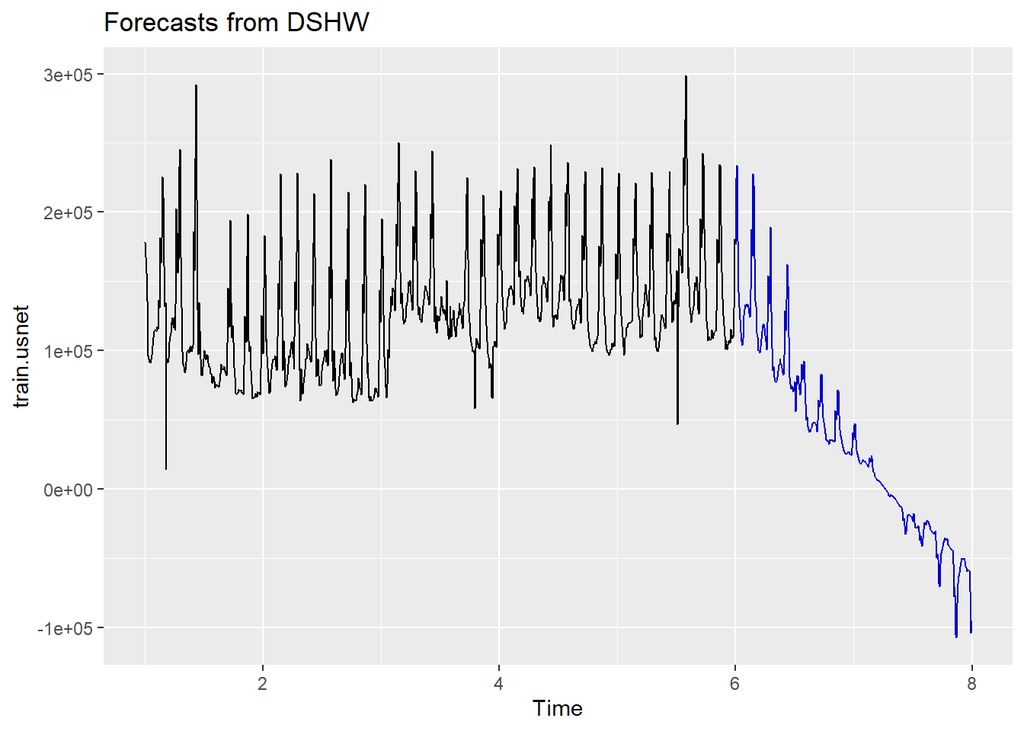

```r
autoplot(hw.usnet)
```

The accuracy of the double-seasonality Holt-Winters model is very poor on the network attack dataset. This is probably because there is greater fluctuation in the data. However, there is still a discernable daily and weekly trend. It seems that the downward trend of the forecast is unduly influenced by the fluctuations in values. We thus adjust the smoothing parameters manually to try to get a better result.

Increasing the alpha (smoothing parameter on the level) and decreasing the beta value (smoothing parameter on the trend) gives a better result. This corresponds to the significant fluctuations in seasonal variance, and the somewhat consistent upward trend.

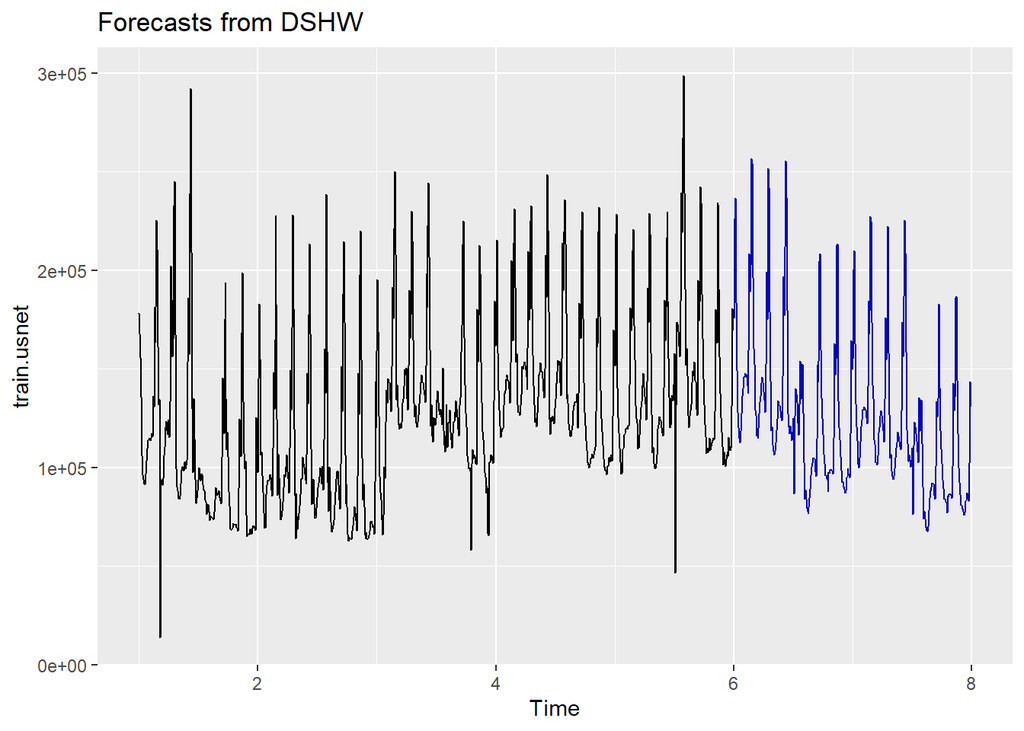

```r
hw.usnet2 <- dshw(train.usnet, period1=24, period2=168, alpha=0.2, beta=0.01)
# summary(hw.usnet)
autoplot(hw.usnet2)
```

```r
accuracy(hw.usnet) # MAPE on train: 7.64
```

```
##                     ME     RMSE      MAE       MPE     MAPE     MASE       ACF1
## Training set -485.9446 16458.82 9240.743 -1.570859 7.640614 0.425212 0.05917761
```

```r
accuracy(hw.usnet2) # MAPE on train: 7.67
```

```
##                    ME    RMSE      MAE       MPE    MAPE      MASE       ACF1
## Training set -506.316 16385.1 9219.797 -1.612282 7.67669 0.4242482 0.07090438
```

The accuracy of both dshw models are comparable.

```r
train.df2 <- data.frame(hw.usnet2)
tail(train.df2)
```

```
##       Point.Forecast
## 7.964       84604.32
## 7.970       84386.50
## 7.976       82995.51
## 7.982      102443.72
## 7.988      143561.01
## 7.994      130850.73
```

```r
net.df$dshw.Predict <- train.df2[1:168,]
net.df[2:5] <- NULL

net.df$datetime <- us.net$datetimelocal[841:1008]
net.df$datetime <- ymd_hms(net.df$datetime)
net.df <- net.df[, c(4,2,1,3)]
net.df$HW.MAE <- abs(net.df$Actual - net.df$Holtwinters.Predict)
net.df$HW.MAPE <- net.df$HW.MAE * 100 / net.df$Actual

HW.MAE <- mean(net.df$HW.MAE)
HW.MAPE <- mean(net.df$HW.MAPE)
HW.MAPE
```

```
## [1] 20.26557
```

```r
net.df$dshw.MAE <- abs(net.df$Actual - net.df$dshw.Predict)
net.df$dshw.MAPE <- net.df$dshw.MAE * 100 / net.df$Actual

dshw.MAE <- mean(net.df$dshw.MAE)
dshw.MAPE <- mean(net.df$dshw.MAPE)
dshw.MAPE
```

```
## [1] 24.10979
```

As above, ARIMA analysis was done in JMP and imported.

```r
#### Import JMP ARIMA files
arimanet <- read_xlsx("analysis/us_predict.xlsx", sheet = 2, range="E504:F671", col_names=c("Predict_222022", "Predict_222122"))
net.df$Arima1 <- arimanet$Predict_222022
net.df$Arima2 <- arimanet$Predict_222122
```